# Vienna_ATTP_20170317

## Modeling With Big Data and Machine Learning

[vahid moosavi](https://vahidmoosavi.com/)

17th March 2017

## Outline

### What is Data Driven Modeling using Machine Learning?

### Some Experimental Applications

```python
import warnings
warnings.filterwarnings("ignore")
import datetime

import pandas as pd
# import pandas.io.data
import numpy as np
import matplotlib
from matplotlib import pyplot as plt
import sys
import sompylib.sompy as SOM# from pandas import Series, DataFrame
pd.__version__
%matplotlib inline
```

# A bit of my background

## Landscape of computational urban modeling from the vision of General Systems Theory

[figure not shown]

## Life and death of computational (Urban) modeling concepts

### Data From Google Ngram Service

[figure not shown]

#### Google Trends

[figure not shown]

# A major shift:

# Knowing Vs. Learning (Theory Driven Vs. Data Driven) Beyond domain expertise

## The primary role of Data in Data Driven Modeling

[figure not shown]

# Machine Learning and Data Driven Modeling together have turned the classical notion of expertise as

“Having the Answers to the Known Questions”

# to

“Learning to Ask Good Questions”

# This means soon we expect that all the classical application domains will be "revisited" or "redefined"!

# My personal research agenda:

## How to get literate in these new fields and new ways of looking at the world?

## How to dive into different application domains (with the classical vision of systems)?

# However, these new fields are also rapidly evolving!

# Then what is Machine Learning and Data Driven Modeling?

# In Terms of Daily Use of ML: We need to be able to speak in this new "LANGUAGE"!

[figure not shown]

# But from an abstract point of view:

# Main elements of data driven modeling (in my opinion) are about:

## 1- Main approaches to represent the "data" and objects of the study

## 2- The architecture of the "models" and their storage capacity in dealing with different levels of complexity

# 1- How to represent the objects via data?

## 1 - Representation of objects based on a priori given features

[figure not shown]

## Main priors:

- **Independece of the objects**
- **Notion of abstract object**

## Examples:

- **representing a house based on its features**
- **A student based on its grade**
- **A country based on its GDP**

## 2- Representation of objects based on other concrete objects: Relational Representation

[figure not shown]

## Main priors:

- **Dependence of the objects to each other**

## Examples:

- **A word in a text**
- **A pixel of an image**
- **A chemical element in a molecule**
- **A specific ingredient in a food receipie**
- **A building in its neighborhood**
- **A Person in a social network**

# The second approach is essentially Data Driven!

## Main reference:

- **Markov 1906**

  #

# 2- Architecture of different modeling approaches and their Storage Capacity

## 1- Classical regression (Least Square Method started from 1800)

```python
N = 500
x1= np.random.normal(loc=17,scale=5,size=N)[:,np.newaxis]
x2= np.random.normal(loc=0,scale=5,size=N)[:,np.newaxis]
y = 3*x1 + np.random.normal(loc=.0, scale=.4, size=N)[:,np.newaxis]
x1 = np.sort(x1)
# x1 = np.random.uniform(size=N)[:,np.newaxis]
# y = np.sin(2*np.pi*x1**3)**3 + .1*np.random.randn(*x1.shape)



# x1= np.random.normal(loc=17,scale=5,size=N)[:,np.newaxis]
x1 = np.random.rand(N) * 10 - 5
x1 = np.sort(x1)
x1 = x1[:,np.newaxis]
noise = 0.1

# y =-.1*x1**3 + 2*x1*x1 + 2*np.sqrt(x1)+ 10*np.random.normal(loc=30.0, scale=4.7, size=len(x1))[:,np.newaxis]

def f(x):
    x = x.ravel()
    return np.exp(-x ** 2) + 1. * np.exp(-(x - 1) ** 2)

y = f(x1) + np.random.normal(0.0, noise, N)
y = y[:,np.newaxis]


# x1= np.random.normal(loc=17,scale=5,size=N)
# x1 = np.sort(x1)
# # x1 = x1[:,np.newaxis]

# def f(x):
#     x = x.ravel()
#     return -.1*x1**3 + 2*x1*x1
# y =f(x1) + 10*np.random.normal(loc=30.0, scale=4.7, size=len(x1))
# y = y[:,np.newaxis]
# print x1.shape, y.shape

def polynomial_regr(degree=1):
    from sklearn.preprocessing import PolynomialFeatures
    from sklearn import linear_model



    X_tr = x1[:].astype(float)
    y_tr = y[:].astype(float)


    poly = PolynomialFeatures(degree=degree)
    X_tr_ = poly.fit_transform(X_tr)
#     X_ts_ = poly.fit_transform(X_ts)

    regr = linear_model.LinearRegression()
    regr.fit(X_tr_, y_tr)


    y_pred_tr = regr.predict(X_tr_)[:]
#     y_pred_ts = regr.predict(X_ts_)[:]
    # Predicting the training data
    plt.plot(X_tr,y_tr,'.b',markersize=6,alpha=.4 );
    plt.plot(X_tr,y_pred_tr,'-r',markersize=10,alpha=1 );
```

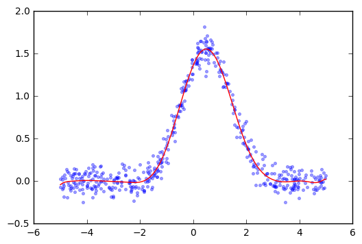

```python
from ipywidgets import interact, HTML, FloatSlider
interact(polynomial_regr,degree=(1,160,1));
```

# This is where we are looking for "one optimum descriptive function"

# I show this with one abstract point

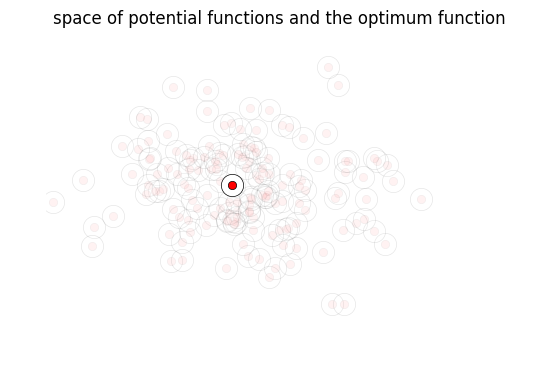

```python
# plt.xlim(2,2)
# plt.ylim(2,2)
for i in range(150):
#     x = 4*np.random.rand()
    x = 2 + np.random.randn()*.04
    y = 2 + np.random.randn()*.04
#     y = 4*np.random.rand()
    plt.plot(x,y,'ow',markersize=16,alpha=.1);
    plt.plot(x,y,'or',markersize=6,alpha=.05);

plt.plot(2,2,'ow',markersize=16);
plt.plot(2,2,'or',markersize=6);
# plt.axis('equal');
plt.axis('off');
plt.title("space of potential functions and the optimum function");
```

## This is a "central memory" and a "global prototype"

- **central memory means that this abstract point can generate complete instance of the objects!**

## And unfortunately, it is not powerful enough and conceptually doesn't fit with data driven modeling

## Usually, the aim is a simple, explanable generalization from the phenomenon under study!

# What if we forget about the single descriptive model?

# 2- Centralized Memory and Distributed Prototypes and Multiple Overall Views

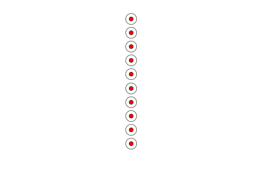

```python
for i in range(5,6,1):
    for j in np.linspace(1,10,num=10):
        plt.plot(i,j,'ow',markersize=16);
        plt.plot(i,j,'or',markersize=6);
plt.xlim(0,10)
plt.ylim(0,11)
# plt.axis('equal');
plt.axis('off');
# plt.title("single storage point");
```

# Higher capacity for dealing with complexity

# Key issue: How to orchestrate these abstract points

- **By looking at different features of the objects**
- **By focusing on different areas of the state space**
- **Many powerful algorithms are in this category**

# This is also called "Manifold Learning"

# Space of potentials

[figure not shown]

# Most of real world applications can be solved with the second approach!

# However, the capacity of the model grows linearly as the function of number of points!

# 3- Distributed Memory and No Explicit Prototypes and No Overall View

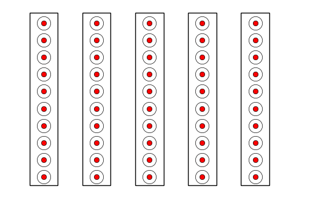

```python
from matplotlib.patches import Rectangle

for i in np.linspace(1,10,num=5):
    currentAxis = plt.gca()
    cx = i-.6
    cy = 1-.5
    currentAxis.add_patch(Rectangle((cx,cy), 1.2, 10.1, fill=None, alpha=1))
    for j in np.linspace(1,10,num=10):

        cx = i-.6
        cy = j-.5
        ax = plt.axes()

        plt.plot(i,j,'ow',markersize=16);
        plt.plot(i,j,'or',markersize=6);
#         ax.arrow(cx+1.2, cy+.5, .7, 0, head_width=0.15, head_length=.1, fc='k', ec='k')


plt.xlim(0,12)
plt.ylim(0,11)
plt.axis('off');
```

## Each point in each layer becomes only a new dimensionality

## In this level the combination of points in vertical and horizontal directions create the full object.

## therefore the memory is distributed and by adding a new layer the capacity of the model grows exponentially!

# This is in my opinion the main feature of the so called Deep Networks and Deep Learning methods